# Aquaponics versus Hydroponics

Comparison of nutrient concentrations recommended for hydroponics with their maximum solubilities under aquaponic conditions

Anıl A. Tellbüscher

2022-07-07

```r
library(XLConnect)
library(tidyverse)
```

# General

Conditions in aquaponic systems differ from those in hydroponics. The main differences with regards to physicochemical conditions are

- pH
- DOM

The question arising is now whether the recommended elemental concentrations for hydroponic nutrient solutions can actually be reached in aquaponic systems from a chemical viewpoint or whether precipitation occurs due to the higher pH in the system.

# 1. Preparations

Nutrient solution composition data presented by Resh (Hydroponic Food Production) was extracted from the book and used for the following calculations.

## 1.1 Load data

```r
getwd()
```

```
## [1] "/Users/anilaxeltellbuescher/Projekte/Projekt18 - PhD-Aquaponics/2 - Nutrient Solubility"
```

```r
# Load Workbook
#resh_hydroponic_plant_production <- loadWorkbook(filename = "/Users/anil/Library/CloudStorage/OneDrive-JihočeskáuniverzitavČeskýchBudějovicích/General/Resh - Hydroponic Plant Production.xlsx")

# Load Workbook
resh_hydroponic_plant_production <- loadWorkbook(filename = "data/Resh - Hydroponic Plant Production.xlsx")
```

```r
# Read Worksheet
# Unit: mg/L
resh_data <- readWorksheet(resh_hydroponic_plant_production, sheet = "nutrient solutions", region = c('A', 'C2:Q50'))
```

```r
molarWeight <- read.csv2('data/molarWeight.csv')
```

## 1.2 Data wrangling

```r
resh_data <- data.frame(resh_data[[2]], row.names = resh_data[[1]][2:49,1])

resh_data <- resh_data[7,]

resh_data <- resh_data %>%
  rename('P' = 'PO4_P_mgL', 'K' = 'K_mgL', 'Ca' = 'Ca_mgL', 'Mg' = 'Mg_mgL', 'S' = 'SO4_S_mgL', 'B' = 'B_mgL', 'Fe' = 'Fe_mgL', 'Mn' = 'Mn_mgL', 'Cu' = 'Cu_mgL', 'Zn' = 'Zn_mgL', 'Na' = 'Na_mgL', 'NH4' = 'NH4_N_mgL', 'Mo' = 'Mo_mgL', 'NO3' = 'NO3_N_mgL', 'Cl' = 'Cl_mgL')

print(resh_data)
```

```
##                            Ca Mg Na   K NH4 NO3  P  S Cl  Fe  Mn   Cu   Zn   B
## Hoagland and Arnon (1938) 160 48 NA 234  14 196 31 64 NA 0.6 0.5 0.02 0.05 0.5
##                             Mo
## Hoagland and Arnon (1938) 0.01
```

## 1.3 Create dataset with target concentrations in hydroponics

The nutrient data is all given in mg/L. These mass concentrations are not suitable for the correction by pH. Thus, data has to be converted into molar concentrations for further calculations.

```r
targetConc <- resh_data %>%

  # Calculate total N (TIN) by summing up NH4 and NO3
  mutate(
    N = NH4 + NO3
  ) %>%
  select(-c('NH4', 'NO3')) %>%

  # Create longtable
  pivot_longer(
    everything(),
    names_to = 'nutrient',
    values_to = 'conc_mgL'
    ) %>%

  drop_na() %>%   # Remove missing values

  #group_by(nutrient) %>%
  #summarise(mean_mgL = mean(concentration)) %>%

  left_join(molarWeight, by = c('nutrient' = 'element')) %>%

  mutate(
    g_per_mol = as.numeric(g_per_mol),
    mol_per_L = conc_mgL * 1e-3 / g_per_mol # Conversion into mol/L
    ) %>%

  arrange(desc(mol_per_L)) %>%

  print()
```

```
## # A tibble: 12 × 4
##    nutrient conc_mgL g_per_mol   mol_per_L
##    <chr>       <dbl>     <dbl>       <dbl>
##  1 N          210         14.0 0.0150
##  2 K          234         39.1 0.00598
##  3 Ca         160         40.1 0.00399
##  4 S           64         32.1 0.00200
##  5 Mg          48         24.3 0.00197
##  6 P           31         31.0 0.00100
##  7 B            0.5       10.8 0.0000463
##  8 Fe           0.6       55.8 0.0000107
##  9 Mn           0.5       54.9 0.00000910
## 10 Zn           0.05      65.4 0.000000765
## 11 Cu           0.02      63.5 0.000000315
## 12 Mo           0.01      96.0 0.000000104
```

## 1.4 Recalculation considering environmental aspects

Due to the fact that conditions in hydroponic systems differ from those observed in aquaculture, some assumptions can be made such as the pH being maintained at acidic levels. Furthermore, it can be assumed that the $CO_{2}$ saturation of the water is likely comparably high because no gas stripping technology is applied and in some greenhouses the atmospheric $CO_{2}$ concentration is even artificially increased. The pH and $p(CO_{2})$ values utilized for the following calculations are thus presentedin the following table.

[output not shown]

The correction of the concentrations for pH can eventually be done using self-written speciation functions.

```r
# Phosphate
source('R/speciation - c_T-PO4.R')

# Hydroxide
source('R/speciation - OH.R')

# Carbonate
source('R/speciation - pCO2-CO3.R')

# Sulfate
source('R/speciation - c_T-SO4.R')
```

Eventually, the functions can be applied to the dataset. **The extra idented rows are a workaround to make *pivot_wider()* work.**

```r
procdata <- targetConc %>%

  select(c(nutrient, mol_per_L)) %>%

      group_by(nutrient) %>% # Workaround pivot_wider()
      mutate(row = row_number()) %>% # Workaround pivot_wider()

  pivot_wider(names_from = nutrient, values_from = mol_per_L) %>%

      select(-row) %>%  # Workaround pivot_wider()


  # Calculate species
  mutate(
    species_PO4_molL = calc_PO4(c_tot = P, pH = pH, form_P = 'po4-p', unit = 'mol'),

    species_OH_molL = calc_OH(pH = pH),

    species_CO3_molL = calc_CO3(pH = pH, pCO2 = pCO2_atm),

    species_SO4_molL = calc_SO4(c_tot = S, pH = pH, form_S = 'SO4-S', unit = 'mol')
  ) %>%

  print()
```

```
## # A tibble: 1 × 16
##        N       K      Ca       S      Mg       P       B      Fe      Mn      Zn
##    <dbl>   <dbl>   <dbl>   <dbl>   <dbl>   <dbl>   <dbl>   <dbl>   <dbl>   <dbl>
## 1 0.0150 0.00598 0.00399 0.00200 0.00197 0.00100 4.63e-5 1.07e-5 9.10e-6 7.65e-7
## # … with 6 more variables: Cu <dbl>, Mo <dbl>, species_PO4_molL <dbl>,
## #   species_OH_molL <dbl>, species_CO3_molL <dbl>, species_SO4_molL <dbl>
```

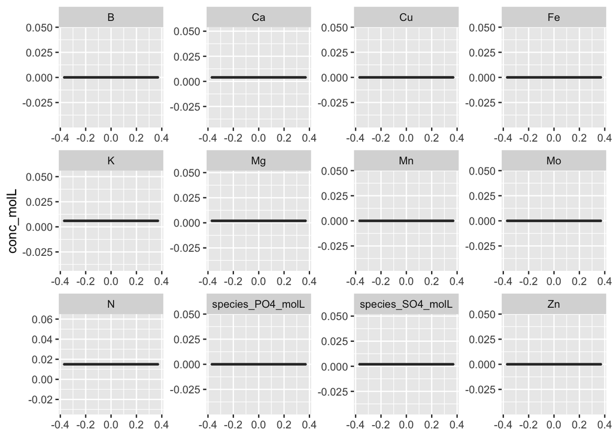

```r
procdata %>%

  select(
    -c(
      P
      ,S
      ,species_OH_molL
      ,species_CO3_molL
    )
  ) %>%

  pivot_longer(
    cols = everything(),
    names_to = 'nutrient',
    values_to = 'conc_molL'
  ) %>%

  drop_na() %>%

  ggplot(aes(y = conc_molL)) +
  geom_boxplot() +
  facet_wrap(facets = vars(nutrient), scales = 'free')
```

The next step after the pH correction is to calculate theoretical lowest (‘worst case’) solubilities of all compounds (‘X_in_XY’ denoting for the theoretical maximum concentration of a compound under the given conditions). Furthermore, a logical test is conducted, assessing whether the recommended concentration is larger than the theoretical solubility. Also, the difference between the recommendation and the theoretical solubility and their proportions are calculated.

```r
# Import solubility data
solubility_data <- read.csv('data/solubilityData_for4-NutrientComparison.csv')

#
plotdata <- procdata %>%

mutate(
    # CaCO3
    Ca_in_CaCO3 = solubility_data$Ks0[which(solubility_data$chemFormula == "CaCO3",)] / species_CO3_molL,
    Ca_found_greater_CaCO3 = Ca > Ca_in_CaCO3,
    CaCO3_diff = Ca - Ca_in_CaCO3,
    CaCO3_prop = Ca / Ca_in_CaCO3,

    # Ca(OH)2
    Ca_in_CaOH2 = solubility_data$Ks0[which(solubility_data$chemFormula == "Ca(OH)2",)] / species_OH_molL^2,
    Ca_found_greater_CaOH2 = Ca > Ca_in_CaOH2,
    CaOH2_diff = Ca - Ca_in_CaOH2,
    CaOH2_prop = Ca / Ca_in_CaOH2,

    # Ca3PO42
    Ca_in_Ca3PO42 = (solubility_data$Ks0[which(solubility_data$chemFormula == "Ca3(PO4)2",)] / species_PO4_molL^2)^(1/3),
    Ca_found_greater_Ca3PO42 = Ca > Ca_in_Ca3PO42,
    Ca3PO42_diff = Ca - Ca_in_Ca3PO42,
    Ca3PO42_prop = Ca / Ca_in_Ca3PO42,


    # CaSO4
    Ca_in_CaSO4 = solubility_data$Ks0[which(solubility_data$chemFormula == "CaSO4",)] / species_SO4_molL,
    Ca_found_greater_CaSO4 = Ca > Ca_in_CaSO4,
    CaSO4_diff = Ca - Ca_in_CaSO4,
    CaSO4_prop = Ca / Ca_in_CaSO4,

    # MgCO3
    Mg_in_MgCO3 = solubility_data$Ks0[which(solubility_data$chemFormula == "MgCO3",)] / species_CO3_molL,
    Mg_found_greater_MgCO3 = Mg > Mg_in_MgCO3,
    MgCO3_diff = Mg - Mg_in_MgCO3,
    MgCO3_prop = Mg / Mg_in_MgCO3,

    # Mg(OH)2
    Mg_in_MgOH2 = solubility_data$Ks0[which(solubility_data$chemFormula == "Mg(OH)2",)] / species_OH_molL^2,
    Mg_found_greater_MgOH2 = Mg > Mg_in_MgOH2,
    MgOH2_diff = Mg - Mg_in_MgOH2,
    MgOH2_prop = Mg / Mg_in_MgOH2,


    # Mg3PO42
    Mg_in_Mg3PO42 = (solubility_data$Ks0[which(solubility_data$chemFormula == "Mg3(PO4)2",)] / species_PO4_molL^2)^(1/3),
    Mg_found_greater_Mg3PO42 = Mg > Mg_in_Mg3PO42,
    Mg3PO42_diff = Mg - Mg_in_Mg3PO42,
    Mg3PO42_prop = Mg / Mg_in_Mg3PO42,

    # FePO4
    Fe_in_FePO4 = solubility_data$Ks0[which(solubility_data$chemFormula == "FePO4 x 2 H2O",)] / species_PO4_molL,
    Fe_found_greater_FePO4 = Fe > Fe_in_FePO4,
    FePO4_diff = Fe - Fe_in_FePO4,
    FePO4_prop = Fe / Fe_in_FePO4,

    # MnCO3
    Mn_in_MnCO3 = solubility_data$Ks0[which(solubility_data$chemFormula == "MnCO3",)] / species_CO3_molL,
    Mn_found_greater_MnCO3 = Mn > Mn_in_MnCO3,
    MnCO3_diff = Mn - Mn_in_MnCO3,
    MnCO3_prop = Mn / Mn_in_MnCO3,

    # Cu3PO42
    Cu_in_Cu3PO42 = (solubility_data$Ks0[which(solubility_data$chemFormula == "Cu3(PO4)2",)] / species_PO4_molL^2)^(1/3),
    Cu_found_greater_Cu3PO42 = Cu > Cu_in_Cu3PO42,
    Cu3PO42_diff = Cu - Cu_in_Cu3PO42,
    Cu3PO42_prop = Cu / Cu_in_Cu3PO42,

    # ZnCO3
    Zn_in_ZnCO3 = solubility_data$Ks0[which(solubility_data$chemFormula == "ZnCO3",)] / species_CO3_molL,
    Zn_found_greater_ZnCO3 = Zn > Zn_in_ZnCO3,
    ZnCO3_diff = Zn - Zn_in_ZnCO3,
    ZnCO3_prop = Zn / Zn_in_ZnCO3,

    # Zn(OH)2
    Zn_in_ZnOH2 = solubility_data$Ks0[which(solubility_data$chemFormula == "Zn(OH)2",)] / species_OH_molL^2,
    Zn_found_greater_ZnOH2 = Zn > Zn_in_ZnOH2,
    ZnOH2_diff = Zn - Zn_in_ZnOH2,
    ZnOH2_prop = Zn / Zn_in_ZnOH2
  )
```

# 2. Comparison between recommendation and theoretical maximum concentration

In the following, the dataset is reduced to the calculated proportions between the concentrations that are recommended and the concentrations that are resulting from the theoretical solubility calculations

```r
plotdata <- plotdata %>%

  select(ends_with('_prop')) %>%

  pivot_longer(
    cols = everything(),
    names_to = 'substance',
    values_to = 'proportion'
  ) %>%

  mutate(
    substance = sub('_prop', '', substance),
    pH = pH,
    pCO2 = pCO2_atm
  ) %>%

  filter(
    proportion != Inf
    ) %>%

  print()
```

```
## # A tibble: 12 × 4
##    substance proportion    pH  pCO2
##    <chr>          <dbl> <dbl> <dbl>
##  1 CaCO3       4.56e- 2     6 0.054
##  2 CaOH2       7.95e-14     6 0.054
##  3 Ca3PO42     1.56e+ 2     6 0.054
##  4 CaSO4       1.62e- 1     6 0.054
##  5 MgCO3       1.11e- 5     6 0.054
##  6 MgOH2       3.52e- 8     6 0.054
##  7 Mg3PO42     9.69e- 2     6 0.054
##  8 FePO4       3.80e+ 0     6 0.054
##  9 MnCO3       1.56e- 2     6 0.054
## 10 Cu3PO42     3.01e- 1     6 0.054
## 11 ZnCO3       2.01e- 4     6 0.054
## 12 ZnOH2       2.55e- 6     6 0.054
```

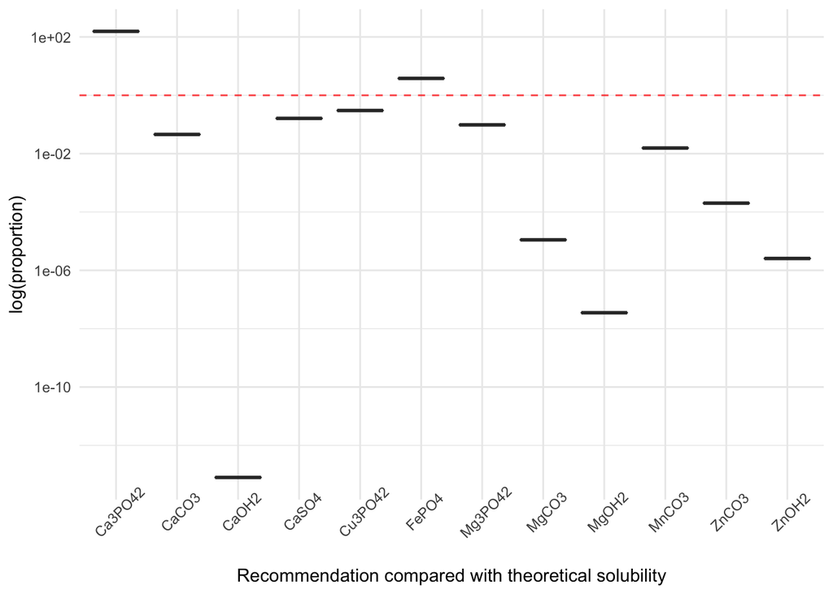

```r
plotdata %>%

  mutate(
    substance = as.factor(substance),
    treshold_label = if_else(proportion > 1, true = '2', false = '1')
    ) %>%

  ggplot(aes(
    x = substance,
    y = proportion,
    fill = treshold_label
    )) +
    geom_boxplot() +
    geom_hline(yintercept = 1, linetype = 'dashed', color = 'red', alpha = 0.75) +
    scale_y_log10() +
    #facet_wrap(facets = vars(substance), scales = 'free') +
    labs(
      x = 'Recommendation compared with theoretical solubility',
      y = 'log(proportion)'
    ) +
    theme_minimal() +
    theme(
      axis.text.x = element_text(angle = 45),
      legend.position = 'none'
      )
```

# 3. Comparison between different environmental conditions

```r
procdata2 <- targetConc %>%

  select(c(nutrient, mol_per_L)) %>%

      group_by(nutrient) %>% # Workaround pivot_wider()
      mutate(row = row_number()) %>% # Workaround pivot_wider()

  pivot_wider(names_from = nutrient, values_from = mol_per_L) %>%

      select(-row) %>%  # Workaround pivot_wider()


  # Calculate species
  mutate(
    species_PO4_molL = calc_PO4(c_tot = P, pH = pH2, form_P = 'po4-p', unit = 'mol'),

    species_OH_molL = calc_OH(pH = pH2),

    species_CO3_molL = calc_CO3(pH = pH2, pCO2 = pCO2_atm2),

    species_SO4_molL = calc_SO4(c_tot = S, pH = pH2, form_S = 'SO4-S', unit = 'mol')
  ) %>%

  print()
```

```
## # A tibble: 1 × 16
##        N       K      Ca       S      Mg       P       B      Fe      Mn      Zn
##    <dbl>   <dbl>   <dbl>   <dbl>   <dbl>   <dbl>   <dbl>   <dbl>   <dbl>   <dbl>
## 1 0.0150 0.00598 0.00399 0.00200 0.00197 0.00100 4.63e-5 1.07e-5 9.10e-6 7.65e-7
## # … with 6 more variables: Cu <dbl>, Mo <dbl>, species_PO4_molL <dbl>,
## #   species_OH_molL <dbl>, species_CO3_molL <dbl>, species_SO4_molL <dbl>
```

```r
plotdata2 <- procdata2 %>%

mutate(
    # CaCO3
    Ca_in_CaCO3 = solubility_data$Ks0[which(solubility_data$chemFormula == "CaCO3",)] / species_CO3_molL,
    Ca_found_greater_CaCO3 = Ca > Ca_in_CaCO3,
    CaCO3_diff = Ca - Ca_in_CaCO3,
    CaCO3_prop = Ca / Ca_in_CaCO3,

    # Ca(OH)2
    Ca_in_CaOH2 = solubility_data$Ks0[which(solubility_data$chemFormula == "Ca(OH)2",)] / species_OH_molL^2,
    Ca_found_greater_CaOH2 = Ca > Ca_in_CaOH2,
    CaOH2_diff = Ca - Ca_in_CaOH2,
    CaOH2_prop = Ca / Ca_in_CaOH2,

    # Ca3PO42
    Ca_in_Ca3PO42 = (solubility_data$Ks0[which(solubility_data$chemFormula == "Ca3(PO4)2",)] / species_PO4_molL^2)^(1/3),
    Ca_found_greater_Ca3PO42 = Ca > Ca_in_Ca3PO42,
    Ca3PO42_diff = Ca - Ca_in_Ca3PO42,
    Ca3PO42_prop = Ca / Ca_in_Ca3PO42,


    # CaSO4
    Ca_in_CaSO4 = solubility_data$Ks0[which(solubility_data$chemFormula == "CaSO4",)] / species_SO4_molL,
    Ca_found_greater_CaSO4 = Ca > Ca_in_CaSO4,
    CaSO4_diff = Ca - Ca_in_CaSO4,
    CaSO4_prop = Ca / Ca_in_CaSO4,

    # MgCO3
    Mg_in_MgCO3 = solubility_data$Ks0[which(solubility_data$chemFormula == "MgCO3",)] / species_CO3_molL,
    Mg_found_greater_MgCO3 = Mg > Mg_in_MgCO3,
    MgCO3_diff = Mg - Mg_in_MgCO3,
    MgCO3_prop = Mg / Mg_in_MgCO3,

    # Mg(OH)2
    Mg_in_MgOH2 = solubility_data$Ks0[which(solubility_data$chemFormula == "Mg(OH)2",)] / species_OH_molL^2,
    Mg_found_greater_MgOH2 = Mg > Mg_in_MgOH2,
    MgOH2_diff = Mg - Mg_in_MgOH2,
    MgOH2_prop = Mg / Mg_in_MgOH2,


    # Mg3PO42
    Mg_in_Mg3PO42 = (solubility_data$Ks0[which(solubility_data$chemFormula == "Mg3(PO4)2",)] / species_PO4_molL^2)^(1/3),
    Mg_found_greater_Mg3PO42 = Mg > Mg_in_Mg3PO42,
    Mg3PO42_diff = Mg - Mg_in_Mg3PO42,
    Mg3PO42_prop = Mg / Mg_in_Mg3PO42,

    # FePO4
    Fe_in_FePO4 = solubility_data$Ks0[which(solubility_data$chemFormula == "FePO4 x 2 H2O",)] / species_PO4_molL,
    Fe_found_greater_FePO4 = Fe > Fe_in_FePO4,
    FePO4_diff = Fe - Fe_in_FePO4,
    FePO4_prop = Fe / Fe_in_FePO4,

    # MnCO3
    Mn_in_MnCO3 = solubility_data$Ks0[which(solubility_data$chemFormula == "MnCO3",)] / species_CO3_molL,
    Mn_found_greater_MnCO3 = Mn > Mn_in_MnCO3,
    MnCO3_diff = Mn - Mn_in_MnCO3,
    MnCO3_prop = Mn / Mn_in_MnCO3,

    # Cu3PO42
    Cu_in_Cu3PO42 = (solubility_data$Ks0[which(solubility_data$chemFormula == "Cu3(PO4)2",)] / species_PO4_molL^2)^(1/3),
    Cu_found_greater_Cu3PO42 = Cu > Cu_in_Cu3PO42,
    Cu3PO42_diff = Cu - Cu_in_Cu3PO42,
    Cu3PO42_prop = Cu / Cu_in_Cu3PO42,

    # ZnCO3
    Zn_in_ZnCO3 = solubility_data$Ks0[which(solubility_data$chemFormula == "ZnCO3",)] / species_CO3_molL,
    Zn_found_greater_ZnCO3 = Zn > Zn_in_ZnCO3,
    ZnCO3_diff = Zn - Zn_in_ZnCO3,
    ZnCO3_prop = Zn / Zn_in_ZnCO3,

    # Zn(OH)2
    Zn_in_ZnOH2 = solubility_data$Ks0[which(solubility_data$chemFormula == "Zn(OH)2",)] / species_OH_molL^2,
    Zn_found_greater_ZnOH2 = Zn > Zn_in_ZnOH2,
    ZnOH2_diff = Zn - Zn_in_ZnOH2,
    ZnOH2_prop = Zn / Zn_in_ZnOH2
  )
```

```r
plotdata2 <- plotdata2 %>%

  select(ends_with('_prop')) %>%

  pivot_longer(
    cols = everything(),
    names_to = 'substance',
    values_to = 'proportion'
  ) %>%

  mutate(
    substance = sub('_prop', '', substance),
    pH = pH2,
    pCO2 = pCO2_atm2
  ) %>%

  filter(
    proportion != Inf
    ) %>%

  print()
```

```
## # A tibble: 12 × 4
##    substance proportion    pH  pCO2
##    <chr>          <dbl> <dbl> <dbl>
##  1 CaCO3       4.56e+ 1   7.5 0.054
##  2 CaOH2       7.95e-11   7.5 0.054
##  3 Ca3PO42     1.56e+ 3   7.5 0.054
##  4 CaSO4       1.62e- 1   7.5 0.054
##  5 MgCO3       1.11e- 2   7.5 0.054
##  6 MgOH2       3.52e- 5   7.5 0.054
##  7 Mg3PO42     9.69e- 1   7.5 0.054
##  8 FePO4       1.20e+ 2   7.5 0.054
##  9 MnCO3       1.56e+ 1   7.5 0.054
## 10 Cu3PO42     3.01e+ 0   7.5 0.054
## 11 ZnCO3       2.01e- 1   7.5 0.054
## 12 ZnOH2       2.55e- 3   7.5 0.054
```

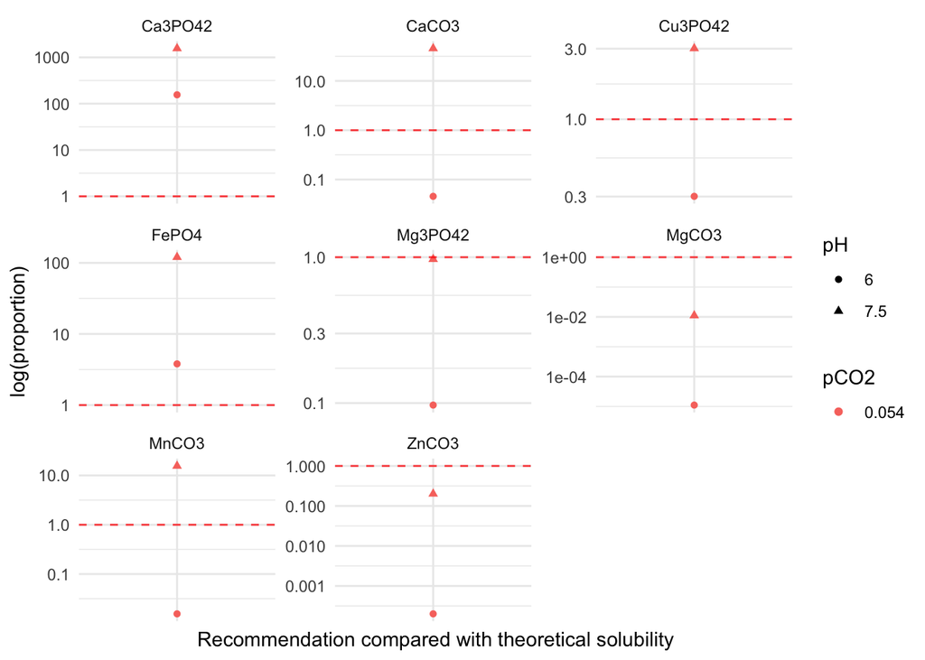

```r
plotdata %>%

  bind_rows(plotdata2) %>%

  mutate(
    substance = as.factor(substance),
    pH = as.factor(pH),
    pCO2 = as.factor(pCO2),
    treshold_label = if_else(proportion > 1, true = '2', false = '1')
    ) %>%

  filter(
    !grepl('OH', substance) &
      !grepl('SO4', substance)
  ) %>%

  ggplot(aes(
    x = substance,
    y = proportion,
    shape = pH,
    color = pCO2
    )) +
    geom_point() +

    geom_hline(yintercept = 1, linetype = 'dashed', color = 'red', alpha = 0.75) +

    scale_y_log10() +

    facet_wrap(facets = vars(substance), scales = 'free') +

    labs(
      x = 'Recommendation compared with theoretical solubility',
      y = 'log(proportion)'
    ) +
    theme_minimal() +
    theme(
      axis.text.x = element_blank()
      )
```